# Building augmented data for multi-state models: the **msmtools** package

version 1.3

Francesco Grossetti francesco.grossetti@unibocconi.it

2017-06-07

# 1 Introduction

Package **msmtools** is an `R` package which has been conceived to facilitate the workflow with longitudinal datasets which need to be analyzed in the context of multi-state models. In particular, **msmtools** acts as the **msm** package companion (Jackson 2011). Moreover, **msmtools** is focused on efficiency and speed, also thanks to package `data.table` (Dowle et al. 2014).

## 1.1 Longitudinal Dataset

Everytime we observe a given subject multiple times, we come up with a longitudinal dataset. This means that measures are repeated $n$ times in a sequence which, in general, may not be equal for all the subjects. Moreover, a longitudinal dataset could be viewed as a multilevel dataset: a first level is given by the subject, and a second level is given by the single observation carried out on that subject. A very common case of longitudinal dataset deals with hospital admissions. A patient, our subject, can have a series of entries which correspond to hospital admissions. Each hospital admission is recorded in a single row of the dataset. Let’s consider a simplified version of the `hosp` dataset which comes with **msmtools** package and represents synthetic hospital admissions for 10 patients. For a detailed description of the dataset, please run `?hosp`. For demonstration purposes, we extract only the first 2 patients, reducing the `hosp` dataset to a test sample of 17 rows per 8 variables as you can see below.

```r
data( hosp )
hosp[ 1:17, .( subj, adm_number, gender, age, label_2,
               dateIN, dateOUT, dateCENS ) ]
```

```
##     subj adm_number gender age label_2     dateIN    dateOUT   dateCENS
##  1:    1          1      F  83    dead 2008-11-30 2008-12-12 2011-04-28
##  2:    1          2      F  83    dead 2009-01-26 2009-02-16 2011-04-28
##  3:    1          3      F  83    dead 2009-05-13 2009-05-15 2011-04-28
##  4:    1          4      F  83    dead 2009-05-20 2009-05-25 2011-04-28
##  5:    1          5      F  83    dead 2009-06-12 2009-06-16 2011-04-28
##  6:    1          6      F  83    dead 2009-06-20 2009-06-25 2011-04-28
##  7:    1          7      F  83    dead 2009-07-17 2009-07-22 2011-04-28
##  8:    1          8      F  84    dead 2010-04-15 2010-04-20 2011-04-28
##  9:    1          9      F  84    dead 2010-10-11 2010-10-14 2011-04-28
## 10:    1         10      F  85    dead 2011-01-14 2011-01-17 2011-04-28
## 11:    1         11      F  85    dead 2011-04-27 2011-04-28 2011-04-28
## 12:    2          1      F  99   alive 2007-09-17 2007-09-27 2012-12-31
## 13:    2          2      F 100   alive 2009-04-09 2009-04-17 2012-12-31
## 14:    2          3      F 103   alive 2012-04-16 2012-04-20 2012-12-31
## 15:    2          4      F 103   alive 2012-04-24 2012-05-19 2012-12-31
## 16:    2          5      F 103   alive 2012-05-20 2012-05-25 2012-12-31
## 17:    2          6      F 103   alive 2012-08-19 2012-08-21 2012-12-31
```

So, these two patients are ‘observed’ 11 and 6 times through years, respectively.

These data format are very common when dealing with observational studies, or with chronic disease monitoring and with hospital admissions recording. In general, they are a well stabilized system to collect information.

## 1.2 Enhancing the Longitudinal Structure with `augment()`

Why the standard longitudinal structure is not enough if a multi-state model has to be run? A first observation could be that we are not able to infer anything about the state in which a given subject (i.e. patient) is at a particular point in time (i.e. hospital admission). The function `augment()` comes into play for this reason: to take advantage of the longitudinal structure in order to extract usable information to fuel a multi-state model. `augment()` takes a longitudinal dataset with exact starting and ending times and reshape it to produce an *augmented* version. For instance, if you apply `augment()` to the dataset above, you get what follows:

```r
hosp_augmented = augment( data = hosp, data_key = subj,
                          n_events = adm_number, pattern = label_2,
                          t_start = dateIN, t_end = dateOUT,
                          t_cens = dateCENS, verbose = FALSE )
hosp_augmented[ 1:35, .( subj, adm_number, gender, age, label_2,
                         augmented, status, n_status ) ]
```

```
##     subj adm_number gender age label_2  augmented status n_status
##  1:    1          1      F  83    dead 2008-11-30     IN     1 IN
##  2:    1          1      F  83    dead 2008-12-12    OUT    1 OUT
##  3:    1          2      F  83    dead 2009-01-26     IN     2 IN
##  4:    1          2      F  83    dead 2009-02-16    OUT    2 OUT
##  5:    1          3      F  83    dead 2009-05-13     IN     3 IN
##  6:    1          3      F  83    dead 2009-05-15    OUT    3 OUT
##  7:    1          4      F  83    dead 2009-05-20     IN     4 IN
##  8:    1          4      F  83    dead 2009-05-25    OUT    4 OUT
##  9:    1          5      F  83    dead 2009-06-12     IN     5 IN
## 10:    1          5      F  83    dead 2009-06-16    OUT    5 OUT
## 11:    1          6      F  83    dead 2009-06-20     IN     6 IN
## 12:    1          6      F  83    dead 2009-06-25    OUT    6 OUT
## 13:    1          7      F  83    dead 2009-07-17     IN     7 IN
## 14:    1          7      F  83    dead 2009-07-22    OUT    7 OUT
```

[output cut: 22 more lines]

Despite the fact that not the same variables have been reported because of layout concerns, two things come up at first sight. In the first place, the number of rows is more than doubled. We now have 35 observations against the initial 17. In the second place, new variables have been created. We will describe them in a minute.

Given the complexity of the data, which can be very high, building a subject specific status flag which marks a its condition at given time steps, could be tricky and computationally intensive. At the end of the study, so at the censoring time, a subject, in general, can be alive, dead inside a given transition if death occurs within `t_start` and `t_end`, or outside a given transition if death occurs otherwise. After $n$ events, the corresponding flag sequence is given by $2n + 1$ for subjects alive and dead outside the transition, while it is just $2n$ for subjects who died inside of it. Let us consider an individual with 3 events. His/her status combinations will be as follows:

- **ALIVE**: IN-OUT | IN-OUT | IN-OUT | OUT
- **DEAD OUT**: IN-OUT | IN-OUT | IN-OUT | DEAD
- **DEAD IN**: IN-OUT | IN-OUT | IN-DEAD.

This operation produces a dataset in the augmented long format which allows to neatly model transitions between the given states.

From now on, we refer to each row as a transition for which we define a state in which the subject lies. `augment()` automatically creates 4 new variables (if argument `more_status` is missing):

- *augmented*: the new timing variable for the process when looking at transitions. If `t_augmented` is missing, then `augment()` creates *augmented* by default. *augmented*. The function looks directly to `t_start` and `t_end` to build it and thus it inherits their class. In particular, if `t_start` is a date format, then `augment()` computes a new variable cast as integer and names it *augmented_int*. If `t_start` is a difftime format, then `augment()` computes a new variable cast as a numeric and names it *augmented_num*;
- *status*: a status flag which looks at `state`. `augment()` automatically checks whether argument `pattern` has 2 or 3 unique values and computes the correct structure of a given subject. The variable is cast as character;
- *status_num*: the corresponding integer version of *status*;
- *n_status*: a mix of *status* and `n_events` cast as character. *n_status* comes into play when a model on the progression of the process is intended.

### 1.2.1 Working correctly with `augment()`

The main and only aim of `augment()` is data wrangling. When dealing with complex structures as longitudinal data are, it is really important to introduce some rules which help the user to not fail when using the function. Here we discuss some of these rules which are mandatory in order to get a correct workflow with `augment()`.

1. Case 1. *integer*:
   - `pattern = 0`: subject is alive at the censoring time;
   - `pattern = 1`: subject is dead during a transition;
   - `pattern = 2`: subject is dead out of a transition.
2. Case 2. *factor*:
   - `pattern = 'alive'`: this is the first level of the factor and corresponds to `pattern = 0` when integer;
   - `pattern = 'dead in'`: this is the second level of the factor and corresponds to `pattern = 1` when integer;
   - `pattern = 'dead out'`: this is the third level of the factor and corresponds to `pattern = 2` when integer;
3. Case 3. *character*:
   - the unique values must be in alphabetical order to resemble the pattern of the integer and factor case.

In case one passes to `pattern` a variable which contains only two unique values, `augment()` automatically detects if the unit has an absorbing state occurred inside or outside a given transition. We suggest to always provide a variable with three unique values because of efficiency and speed.  
Everything else different from what described above will inevitably produce wrong behaviour of `augment()` with and uncorrect results.

The second important argument is `state`. This is passed as a list and contains the status flags which will be used to compute all the status variables for the process. The length of `state` is 3, no less, no more and comes with a default given by: `state = list( 'IN', 'OUT', 'DEAD' )`. The order is important here too. The status flags must be passed such that the first one (`'IN'`) represents the first state (in `hosp`, being inside a hospital), the second one represents the second state (in `hosp`, being outside a hospital), and the third one represents the absorbing state (in `hosp`, being dead inside or outside a hospital). As you can tell, this peculiar structure is typical of hospital admissions, where a patient can enter a hospital, can be discharged from it, or can die. As we have already see, the `'DEAD'` status is reached no matter if the subject has died inside or outside a transition (i.e. in our case, inside or outside the hospital). One can change the flags in `state`, but they must be exactly 3. One may need a higher level of complexity when specifying the states of subjects. This will be discussed in the next section where `state` acts as the main indicator of states.

From version 1.2, `augment()` no longer checks the presence of missing data in the arguments passed to it. In fact, the new argument `check_NA` has been introduced and set to `FALSE` by default. Again, this is due because `augment()` has been developed just for restructuring data. The proceduring of searching for missing data is computationally intensive and could cause memory overheads. When dealing with very highly dimensional dataset, this becomes very unfeasible. We then suggest to perform all these types of checks before running `augment()`. If one really wants to run this procedure, can set `check_NA = TRUE` and detection will be performed over `data_key`, `n_events`, `pattern`, `t_start` and `t_end`. Beware, that no missing imputation or deletion is carried out. If any missing value is found, then `augment()` stops with error asking you to fix the problem.

## 1.3 What if a more complex status structure is needed?

`augment()` by default takes a very simple status structure given by 3 different values. In general, this is enough to define a multi-state model. But what if we need a more complex structure. Let’s consider again the dataset `hosp` for the 3rd, 4th, 5th, and 6th patient with the following variables:

```r
hosp[ 18:28, .( subj, adm_number, rehab, it, rehab_it,
                dateIN, dateOUT, dateCENS ) ]
```

```
##     subj adm_number rehab it rehab_it     dateIN    dateOUT   dateCENS
##  1:    3          1     0  0       df 2012-09-18 2012-09-27 2012-12-31
##  2:    3          2     0  1       it 2012-11-28 2012-12-15 2012-12-31
##  3:    3          3     1  0    rehab 2012-12-18 2012-12-28 2012-12-31
##  4:    4          1     0  0       df 2008-08-13 2008-09-20 2012-12-31
##  5:    4          2     0  0       df 2012-03-18 2012-03-19 2012-12-31
##  6:    4          3     0  1       it 2012-07-02 2012-07-20 2012-12-31
##  7:    5          1     0  0       df 2006-02-09 2006-02-25 2008-04-16
##  8:    6          1     0  0       df 2009-03-05 2009-03-16 2010-12-19
##  9:    6          2     0  0       df 2009-07-06 2009-07-20 2010-12-19
## 10:    6          3     0  0       df 2010-11-17 2010-11-23 2010-12-19
## 11:    6          4     0  0       df 2010-12-05 2010-12-19 2010-12-19
```

As you can see, we have two variables which take into account the type of hospital admission. *rehab* marks a rehabilitation admission while *it* marks an intensive therapy one. They are both binary and integer variables, so one can compose them to get something which is informative and, at the same time, usable in the context of ‘making a status’. We then created the variable *rehab_it* which marks all the information in one place and it is a character. You can pass *rehab_it* to the argument `more_status` to tell `augment()` to add these information into a new structure. Now, it is important to remember that `augment()` introduces some rules when you require to compute a more complex status structure. As you can see from the dataset, many values of *rehab_it* are set to `df`. This stands for ‘default’ and when `augment()` finds it, it just compute the default status you already passed to argument state (i.e. in this case, it can be ‘IN’, ‘OUT’, or ‘DEAD’). The argument `more_status` always looks for the value `df`, hence whenever you need to specify a default transition make sure to label it with this value. So, if we run `augment()` on this sample, we obtain the following:

```r
hosp_augmented_more = augment( data = hosp, data_key = subj,
                               n_events = adm_number, pattern = label_2,
                               t_start = dateIN, t_end = dateOUT,
                               t_cens = dateCENS, more_status = rehab_it,
                               verbose = FALSE )
hosp_augmented_more[ 36:60, .( subj, adm_number, rehab_it,
                               augmented, status, status_exp, n_status_exp ) ]
```

```
##     subj adm_number rehab_it  augmented status status_exp n_status_exp
##  1:    3          1       df 2012-09-18     IN      df_IN      1 df_IN
##  2:    3          1       df 2012-09-27    OUT     df_OUT     1 df_OUT
##  3:    3          2       it 2012-11-28     IN      it_IN      2 it_IN
##  4:    3          2       it 2012-12-15    OUT     it_OUT     2 it_OUT
##  5:    3          3    rehab 2012-12-18     IN   rehab_IN   3 rehab_IN
##  6:    3          3    rehab 2012-12-28    OUT  rehab_OUT  3 rehab_OUT
##  7:    3          3    rehab 2012-12-28    OUT  rehab_OUT  3 rehab_OUT
##  8:    4          1       df 2008-08-13     IN      df_IN      1 df_IN
##  9:    4          1       df 2008-09-20    OUT     df_OUT     1 df_OUT
## 10:    4          2       df 2012-03-18     IN      df_IN      2 df_IN
## 11:    4          2       df 2012-03-19    OUT     df_OUT     2 df_OUT
## 12:    4          3       it 2012-07-02     IN      it_IN      3 it_IN
## 13:    4          3       it 2012-07-20    OUT     it_OUT     3 it_OUT
## 14:    4          3       it 2012-07-20    OUT     it_OUT     3 it_OUT
## 15:    5          1       df 2006-02-09     IN      df_IN      1 df_IN
## 16:    5          1       df 2006-02-25    OUT     df_OUT     1 df_OUT
## 17:    5          1       df 2008-04-16   DEAD       DEAD         DEAD
## 18:    6          1       df 2009-03-05     IN      df_IN      1 df_IN
## 19:    6          1       df 2009-03-16    OUT     df_OUT     1 df_OUT
## 20:    6          2       df 2009-07-06     IN      df_IN      2 df_IN
## 21:    6          2       df 2009-07-20    OUT     df_OUT     2 df_OUT
## 22:    6          3       df 2010-11-17     IN      df_IN      3 df_IN
## 23:    6          3       df 2010-11-23    OUT     df_OUT     3 df_OUT
## 24:    6          4       df 2010-12-05     IN      df_IN      4 df_IN
## 25:    6          4       df 2010-12-19   DEAD       DEAD         DEAD
##     subj adm_number rehab_it  augmented status status_exp n_status_exp
```

- *status_exp*: is the direct expansion of status and the variable you passed to `more_status`, which in this case is *rehab_it*. The function composes them by pasting a ’_’ in between. This is the main reason why it is worth to build a character variable if you know you need to fuel it in as an indicator of a more complex status structure;
- *status_exp_num*: the corresponding integer version of *status_exp*;
- *n_status_exp*: similar to what has been done before, `augment()` mixes information coming from the current expandend status and the number of admission to give you the time evolution of the process.

## 1.4 Polishing the augmented data

From version 1.3, **msmtools** gained the new function `polish()` which adds support in the preprocessing phase. The function detects whether there are transitions which occur at the same time but land on different states within a subject as specified by `data_key`. `polish()` needs to be run on an augmented dataset as computed by `augment()`. It then checks the presence of duplicates trough the `time` parameter which refers to the new time variable for the process. By default, `polish()` searches for either `augmented_int` or `augmented_num` depending on what `augment()` detected during the reshaping procedure.

# 2 Graphical Assessment of a Multi-state Model

**msmtools** has been mainly developed to easily manage and work with longitudinal datasets which need to be restructured in order to get msm to work properly.

However, **msmtools** comes with two more functions which try to address graphically and in a very efficient way the problem of the Goodness-of-Fit (GoF) for a multi-state model. When dealing with this type of models, GoF is always a tough quest. Furthermore, up to now, no formal statistical tests are defined when a multi-state model is computed within an exact time framework (Titman and Sharples 2009) (Titman and Sharples 2008).

## 2.1 Comparing fitted and empirical survival with `survplot()`

One of the most common graphical method to assess whether a multi-state model is behaving the way we expect, is to compare the empirical survival with the fitted one. `survplot()` helps out doing this and few more things. The function is a wrapper of the already known `plot.survfit.msm()` from the package **msm**.

Suppose we ran a multi-state model on dataset hosp with the following code:

```r
# let's define the initial transition matrix for our model
Qmat = matrix( data = 0, nrow = 3, ncol = 3, byrow = TRUE )
Qmat[ 1, 1:3 ] = 1
Qmat[ 2, 1:3 ] = 1
colnames( Qmat ) = c( 'IN', 'OUT', 'DEAD' )
rownames( Qmat ) = c( 'IN', 'OUT', 'DEAD' )
Qmat
```

```
##      IN OUT DEAD
## IN    1   1    1
## OUT   1   1    1
## DEAD  0   0    0
```

```r
# attaching the msm package and running the model using
# gender and age as covariates
library( msm )
msm_model = msm( status_num ~ augmented_int,
                 subject = subj, data = hosp_augmented,
                 covariates = ~ gender + age,
                 exacttimes = TRUE, gen.inits = TRUE,
                 qmatrix = Qmat, method = 'BFGS',
                 control = list( fnscale = 6e+05, trace = 0,
                                 REPORT = 1, maxit = 10000 ) )
```

We now have a multi-state model for which we can carry out some graphical inspections. So, we want a simple comparison between the fitted survival curve and the empirical one, computed using the Kaplan-Meier estimator. The code is as follows:

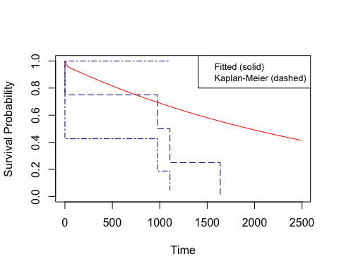

```r
survplot( msm_model, km = TRUE, ci = 'none',
          verbose = FALSE, devnew = FALSE )
```

With no surprises, the plot is not so satisfying due to the really small dataset we provided.

Now, `survplot()` takes several parameters, many of them come with a default value. For instance, the figureabove has been computed for a transition (IN - DEAD). We can pass to argument `from` any starting state we want. If `to` is missing, `survplot()` will check what is the higher value in the corresponding `msm` object and grabs it. Of course, you are free to compute any survival you want, given the transition is allowed in the initial transition matrix `Qmat`. Let’s plot the survival comparison for the transition (OUT - DEAD):

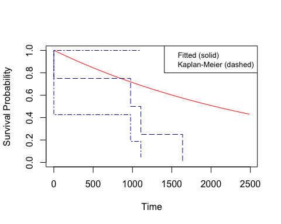

```r
survplot( msm_model, km = TRUE, from = 2, ci = 'none',
          verbose = FALSE, devnew = FALSE )
```

If we do not want to show the Kaplan-Meier, we can pass `km = FALSE`, which is the default.

### 2.1.1 Defining a custom time sequence

By default `survplot()` computes the fitted survival on a given grid. The number of grid points is given by `grid`. In some cases, one would like to pass a custom time sequence. This can be achieved by passing the argument `times` a numeric vector. Now `grid` is ignored.

Consider our dataset and suppose we want to compute a fitted survival only fo specific points in time. The following code addresses this request.

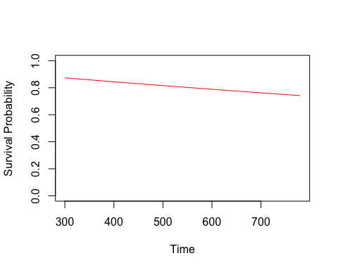

```r
time_seq = seq( 300, 800, by = 30 )
survplot( msm_model, times = time_seq, ci = 'none',
          verbose = FALSE, devnew = FALSE )
```

### 2.1.2 Obtaining the dataset for the Kaplan-Meier

It is possible to tell `survplot()` to return the associated Kaplan-Meier dataset by setting `return.km = TRUE`. This fastly computes the data through `data.table`. Passing only `km = TRUE` won’t return any data, even if they must be computed anyway to plot results.

```r
survplot( msm_model, ci = 'none', return.km = TRUE,
          verbose = FALSE, do.plot = FALSE )
```

No results are printed. If you want to store the information in the current environment, you must assign `survplot()` to an object as follows:

```r
# running survplot() and assigning it to an object
km_data = survplot( msm_model, ci = 'none', return.km = TRUE,
                    verbose = FALSE, do.plot = FALSE )

# let's see the dataset
head( km_data )
```

```
##    subject mintime mintime_exact anystate
## 1:       1   15092          1107        1
## 2:       5   13985             0        1
## 3:       6   14962           977        1
## 4:       7   15623          1638        1
```

The structure of the data is consistent. `survplot()` always computes a dataset in wide format, as requested by `survfit` with 3 columns:

- *subject*: the ordered subject ID as passed to `msm()` function;
- *mintime*: the time at which the event occurred;
- *anystate*: tansition indicator to compute the Kaplan-Meier.

The only modification you might encounter really depends on argument `exacttimes`. This is inherited from `msm()` function whose aim was to tell the model that transitions occurred at exact and known times, including deaths. This is the main reason why this argument should always be set the same way you have set it in `msm()`. In our case, we do have a multi-state model in which transitions are well known and exact as you can see from the `msm()` call above. `survplot()` puts `exacttimes = TRUE` by default so we don’t have to worry about it. So, when `exacttimes = TRUE`, `survplot()` adds a new time variable which provides the relative time for each transition within a given subject. For instance, `km_data` has another column named *mintime_exact* which is cast the same way of *augmented*.

### 2.1.3 Obtaining the dataset for the fitted survival

Similarly to what done for the Kaplan-Meier, it is possible to obtain the data used to compute the fitted survival as well. This can be achieve by setting `return.p = TRUE`. If `times` is passed, then the resulting dataset will have as many rows as the elements in `times`. If `times` is missing, then `survplot()` uses `grid` to know how many time points are requested. Below there is the snippet that addresses what described.

```r
survplot( msm_model, ci = 'none', grid = 10, return.p = TRUE,
          verbose = FALSE, do.plot = FALSE )
```

As before, saving the data in the current environment follows the same procedure as seen before:

```r
# running survplot() and assigning it to an object
fitted_data = survplot( msm_model, ci = 'none', grid = 10, return.p = TRUE,
                        verbose = FALSE, do.plot = FALSE )

# let's see the dataset
fitted_data
```

```
##       time  probs
##  1:    1.0 0.9957
##  2:  252.4 0.8875
##  3:  503.8 0.8149
##  4:  755.2 0.7483
##  5: 1006.6 0.6871
##  6: 1258.0 0.6309
##  7: 1509.4 0.5793
##  8: 1760.8 0.5319
##  9: 2012.2 0.4884
## 10: 2263.6 0.4485
```

The structure of the data is consistent here too. `survplot()` always computes a dataset in wide format with 2 columns:

- *time*: time at which to compute the fitted survival. It can be obtained either by `grid` or by `times` so that the cardinality of the data depends on them;
- *probs*: the corresponding value of the fitted survival.

Of course, you can request `survplot()` to return both the datasets by setting just `return.all = TRUE`. Below you can see the code and the output when no assignment is done and when you save the data into a new object in the environment.

```r
# just running survplot()
survplot( msm_model, ci = 'none', grid = 10, return.all = TRUE,
                     verbose = FALSE, do.plot = FALSE )

# running survplot() and assigning it to an object
all_data = survplot( msm_model, ci = 'none', grid = 10,
                     return.all = TRUE,
                     verbose = FALSE, do.plot = FALSE )

# let's see the datasets
all_data
```

```
## $km
##    subject mintime mintime_exact anystate
## 1:       1   15092          1107        1
## 2:       5   13985             0        1
## 3:       6   14962           977        1
## 4:       7   15623          1638        1
##
## $fitted
##       time  probs
##  1:    1.0 0.9957
##  2:  252.4 0.8875
##  3:  503.8 0.8149
##  4:  755.2 0.7483
##  5: 1006.6 0.6871
##  6: 1258.0 0.6309
##  7: 1509.4 0.5793
##  8: 1760.8 0.5319
##  9: 2012.2 0.4884
## 10: 2263.6 0.4485
```

`all_data` is a list of two elements of class `data.table`. If you want to split up the datasets, just use common syntax:

```r
# do not extract data using just one [].
# This keeps the class, so it returns a list
km_data_wrong = all_data[ 1 ]
# extracting data using the list way so be careful to use double []
km_data_1 = all_data[[ 1 ]]
# extracting data using the '$' access operator
km_data_2 = all_data$km
identical( km_data_wrong, km_data_1 )
```

```
## [1] FALSE
```

```r
identical( km_data_1, km_data_2 )
```

```
## [1] TRUE
```

```r
km_data_1
```

```
##    subject mintime mintime_exact anystate
## 1:       1   15092          1107        1
## 2:       5   13985             0        1
## 3:       6   14962           977        1
## 4:       7   15623          1638        1
```

```r
fitted_data_1 = all_data[[ 2 ]]
fitted_data_2 = all_data$fitted
identical( fitted_data_1, fitted_data_2 )
```

```
## [1] TRUE
```

```r
fitted_data_1
```

```
##       time  probs
##  1:    1.0 0.9957
##  2:  252.4 0.8875
##  3:  503.8 0.8149
##  4:  755.2 0.7483
##  5: 1006.6 0.6871
##  6: 1258.0 0.6309
##  7: 1509.4 0.5793
##  8: 1760.8 0.5319
##  9: 2012.2 0.4884
## 10: 2263.6 0.4485
```

### 2.1.4 The plot layering

Multi-state models, as their name suggests, are specifically designed to work when more than one status exists. Infact, they tipically work when more than 2 status are present. In our example, we have 3 states: `'IN`, `'OUT'`, `'DEAD`. Now, what if we want to plot on the same device more than just one fitted survival curve? Suppose we want to plot the expected survival computed from state 1 and 2. That means, from `'IN` and `'OUT'` to `'DEAD'`. The plot layering addresses exactly this problem and `survplot()` supports this with the argument `add`. Let’s see this in the following example:

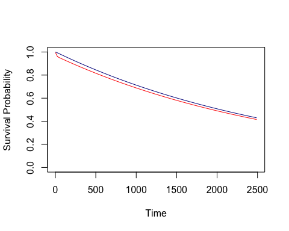

```r
# plotting the first survival from state 'IN'
survplot( msm_model, from = 1, devnew = FALSE, verbose = FALSE )

# plotting the first survival from state 'OUT'
survplot( msm_model, from = 2, add = TRUE, col.fit = 'darkblue',
          devnew = FALSE, verbose = FALSE )
```

## 2.2 Comparing expected and observed prevalences with `prevplot()`

A second graphical tool which helps us in the attempt to understand the goodness of the model is given by comparing the expected and observed prevalences (Gentleman et al. 1994). `prevplot()` is a wrapper of the `plot.prevalence.msm()` function inside the **msm** package but, again, it does more things.

Consider the multi-state model we have built above. We can compute the prevalences using `prevalence.msm()` function. This produces a named list which will be used inside `prevplot()`. For instance, running the following code produces a plot of prevalences for each state of the model.

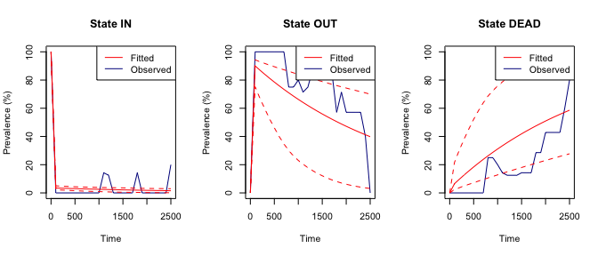

```r
# defining the times at which compute the prevalences
t_min = min( hosp_augmented$augmented_int )
t_max = max( hosp_augmented$augmented_int )
steps = 100L

# computing prevalences
prev = prevalence.msm( msm_model, covariates = 'mean', ci = 'normal',
                            times = seq( t_min, t_max, steps ) )

# and plotting them using prevplot()
prevplot( msm_model, prev, ci = TRUE, devnew = FALSE, verbose = FALSE )
```

It is mandatory for `prevplot()` to work with a `msm` object and a list compute by `prevalence.msm` are passed.

It is also possibile to plot the following statistic:

$$M = \frac{(O_{is} - E_{is})^2} {E_{is}}$$
which gives an idea of the deviance from the Markov model. This is computed according to Titman and Sharples (2008). The following code addresses this request.

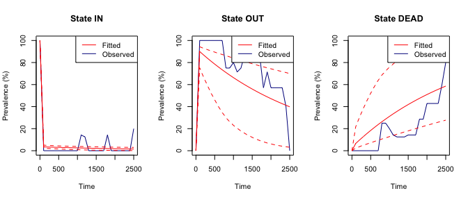

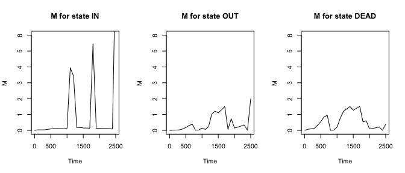

```r
prevplot( msm_model, prev, M = TRUE, ci = TRUE,
          devnew = FALSE, verbose = FALSE )
```

## 2.3 Further details on specific arguments

We are not going to discuss every arguments inside every function. This paragraph serves as a guideline to better exploit **msmtools**. We have developed the package by paying lot of attention to the consistency of the code throughout the functions.

For those of you who are more confortable with objects of class `data.frame` with no compromises, both `augment()` and `survplot()` can manage that with the argument `convert = TRUE`. By default, `convert` is set to `FALSE` in order to incentivize a more efficient coding.

Moreover, you can find the argument `verbose` anywhere in the package. This is useful when you do not want to be informed about anything that is happening internally with the only exception for warnings and of course errors. If quiet is your mood, then you may want to set `verbose = FALSE`.

A third argument which is shared between `survplot()` and `prevplot()` is `devnew`. This is a purely graphical parameter which is set to `TRUE` by default. It allows you to decide whether to plot on a new graphical device called with `dev.new()` by default. If you set `devnew = FALSE`, then the plot is overwritten according to `dev.cur()`. There exist two caveat: the former is that `devnew` is bypassed if the argument `add = TRUE` is passed to `survplot()`. This means that, when you want to add a new layer to an existing plot (with `add`), it does not make any sense to let the function using a new device. Hence, `devnew` is simply ignored. The latter is that, even you can set `devnew = FALSE` in `prevplot()`, one should keep it as the default. If you set it to `FALSE` and you want to plot `M` by setting `M = TRUE`, then this plot overwrites the prevalence one.

# References

Dowle, M., T. Short, S. Lianoglou, A. Srinivasan with contributions from R. Saporta, and E. Antonyan. 2014. *`data.table`: Extension of `data.frame`*. http://CRAN.R-project.org/package=data.table.

Gentleman, RC, JF Lawless, JC Lindsey, and P Yan. 1994. “Multi-State Markov Models for Analysing Incomplete Disease History Data with Illustrations for Hiv Disease.” *Statistics in Medicine* 13 (8). Wiley Online Library: 805–21.

Jackson, C. H. 2011. “Multi-State Models for Panel Data: The `msm` Package for R.” *Journal of Statistical Software* 38 (8): 1–29.

Titman, Andrew C, and Linda D Sharples. 2008. “A General Goodness-of-Fit Test for Markov and Hidden Markov Models.” *Statistics in Medicine* 27 (12). Wiley Online Library: 2177–95.

———. 2009. “Model Diagnostics for Multi-State Models.” *Statistical Methods in Medical Research*. SAGE Publications.